# Google Data Analytics Capstone

### **PHASE THREE: PROCESS**

We will focus on daily records for activity, sleep and weight tracking information to inform the stakeholders of the trends their users are exhibiting. Unnecessary columns from the sleep and weight data sets have been omitted as they do not add to the analysis and were able to be condensed into a smaller data set that included user id, date and one variable to allow for tallying of records.

We chose to complete this analysis using RStudio primarily, we utilized Googlesheets and BiqQuery to verify some of our functions throughout but ultimately RStudio accomplished everything we set out to do.

**Identifying Outliers and Errors**

```r
daily_sleep %>%
  group_by(TotalMinutesAsleep >480) %>%
  tally()
```

```
## # A tibble: 2 × 2
##   `TotalMinutesAsleep > 480`     n
##   <lgl>                      <int>
## 1 FALSE                        298
## 2 TRUE                         115
```

```r
daily_activity %>%
  group_by(SedentaryMinutes > 960, TotalSteps <100) %>%
  tally()
```

```
## # A tibble: 4 × 3
## # Groups:   SedentaryMinutes > 960 [2]
##   `SedentaryMinutes > 960` `TotalSteps < 100`     n
##   <lgl>                    <lgl>              <int>
## 1 FALSE                    FALSE                405
## 2 FALSE                    TRUE                   5
## 3 TRUE                     FALSE                448
## 4 TRUE                     TRUE                  82
```

Of note: There were several entries with sleep well above 480 minutes which would be 8 hours per day, while this does seem unusual the entries were not contained to a single user. There were also many entries with 16 hours or more of sedentary minutes, 82 of these also had fewer than 100 steps per day. There is not an adequate metric for disqualifying, nullifying these entries did not seem appropriate.

#### Clean up the data

```r
daily_activities <- clean_names(daily_activity)
daily_sleep_log <- clean_names(daily_sleep)
weights_log <- clean_names(weight_log)
```

**Preview the data**

```r
colnames(daily_activities)
```

```
##  [1] "id"                         "activity_date"
##  [3] "total_steps"                "total_distance"
##  [5] "tracker_distance"           "logged_activities_distance"
##  [7] "very_active_distance"       "moderately_active_distance"
##  [9] "light_active_distance"      "sedentary_active_distance"
## [11] "very_active_minutes"        "fairly_active_minutes"
## [13] "lightly_active_minutes"     "sedentary_minutes"
## [15] "calories"
```

```r
colnames(daily_sleep_log)
```

```
## [1] "id"                   "sleep_day"            "total_sleep_records"
## [4] "total_minutes_asleep" "total_time_in_bed"
```

```r
colnames(weights_log)
```

```
## [1] "id"               "date"             "weight_kg"        "weight_pounds"
## [5] "fat"              "bmi"              "is_manual_report" "log_id"
```

```r
head(daily_activities)
```

```
##           id activity_date total_steps total_distance tracker_distance
## 1 1503960366     4/12/2016       13162           8.50             8.50
## 2 1503960366     4/13/2016       10735           6.97             6.97
## 3 1503960366     4/14/2016       10460           6.74             6.74
## 4 1503960366     4/15/2016        9762           6.28             6.28
## 5 1503960366     4/16/2016       12669           8.16             8.16
## 6 1503960366     4/17/2016        9705           6.48             6.48
##   logged_activities_distance very_active_distance moderately_active_distance
## 1                          0                 1.88                       0.55
## 2                          0                 1.57                       0.69
## 3                          0                 2.44                       0.40
## 4                          0                 2.14                       1.26
## 5                          0                 2.71                       0.41
## 6                          0                 3.19                       0.78
##   light_active_distance sedentary_active_distance very_active_minutes
## 1                  6.06                         0                  25
## 2                  4.71                         0                  21
## 3                  3.91                         0                  30
## 4                  2.83                         0                  29
## 5                  5.04                         0                  36
## 6                  2.51                         0                  38
##   fairly_active_minutes lightly_active_minutes sedentary_minutes calories
## 1                    13                    328               728     1985
## 2                    19                    217               776     1797
## 3                    11                    181              1218     1776
## 4                    34                    209               726     1745
## 5                    10                    221               773     1863
## 6                    20                    164               539     1728
```

```r
head(daily_sleep_log)
```

```
##           id             sleep_day total_sleep_records total_minutes_asleep
## 1 1503960366 4/12/2016 12:00:00 AM                   1                  327
## 2 1503960366 4/13/2016 12:00:00 AM                   2                  384
## 3 1503960366 4/15/2016 12:00:00 AM                   1                  412
## 4 1503960366 4/16/2016 12:00:00 AM                   2                  340
## 5 1503960366 4/17/2016 12:00:00 AM                   1                  700
## 6 1503960366 4/19/2016 12:00:00 AM                   1                  304
##   total_time_in_bed
## 1               346
## 2               407
## 3               442
## 4               367
## 5               712
## 6               320
```

```r
head(weights_log)
```

```
##           id                  date weight_kg weight_pounds fat   bmi
## 1 1503960366  5/2/2016 11:59:59 PM      52.6      115.9631  22 22.65
## 2 1503960366  5/3/2016 11:59:59 PM      52.6      115.9631  NA 22.65
## 3 1927972279  4/13/2016 1:08:52 AM     133.5      294.3171  NA 47.54
## 4 2873212765 4/21/2016 11:59:59 PM      56.7      125.0021  NA 21.45
## 5 2873212765 5/12/2016 11:59:59 PM      57.3      126.3249  NA 21.69
## 6 4319703577 4/17/2016 11:59:59 PM      72.4      159.6147  25 27.45
##   is_manual_report       log_id
## 1             True 1.462234e+12
## 2             True 1.462320e+12
## 3            False 1.460510e+12
## 4             True 1.461283e+12
## 5             True 1.463098e+12
## 6             True 1.460938e+12
```

```r
glimpse(daily_activities)
```

```
## Rows: 940
## Columns: 15
## $ id                         <dbl> 1503960366, 1503960366, 1503960366, 1503960…
## $ activity_date              <chr> "4/12/2016", "4/13/2016", "4/14/2016", "4/1…
## $ total_steps                <int> 13162, 10735, 10460, 9762, 12669, 9705, 130…
## $ total_distance             <dbl> 8.50, 6.97, 6.74, 6.28, 8.16, 6.48, 8.59, 9…
## $ tracker_distance           <dbl> 8.50, 6.97, 6.74, 6.28, 8.16, 6.48, 8.59, 9…
## $ logged_activities_distance <dbl> 0, 0, 0, 0, 0, 0, 0, 0, 0, 0, 0, 0, 0, 0, 0…
## $ very_active_distance       <dbl> 1.88, 1.57, 2.44, 2.14, 2.71, 3.19, 3.25, 3…
## $ moderately_active_distance <dbl> 0.55, 0.69, 0.40, 1.26, 0.41, 0.78, 0.64, 1…
## $ light_active_distance      <dbl> 6.06, 4.71, 3.91, 2.83, 5.04, 2.51, 4.71, 5…
## $ sedentary_active_distance  <dbl> 0, 0, 0, 0, 0, 0, 0, 0, 0, 0, 0, 0, 0, 0, 0…
## $ very_active_minutes        <int> 25, 21, 30, 29, 36, 38, 42, 50, 28, 19, 66,…
## $ fairly_active_minutes      <int> 13, 19, 11, 34, 10, 20, 16, 31, 12, 8, 27, …
## $ lightly_active_minutes     <int> 328, 217, 181, 209, 221, 164, 233, 264, 205…
## $ sedentary_minutes          <int> 728, 776, 1218, 726, 773, 539, 1149, 775, 8…
## $ calories                   <int> 1985, 1797, 1776, 1745, 1863, 1728, 1921, 2…
```

```r
glimpse(daily_sleep_log)
```

```
## Rows: 413
## Columns: 5
## $ id                   <dbl> 1503960366, 1503960366, 1503960366, 1503960366, 1…
## $ sleep_day            <chr> "4/12/2016 12:00:00 AM", "4/13/2016 12:00:00 AM",…
## $ total_sleep_records  <int> 1, 2, 1, 2, 1, 1, 1, 1, 1, 1, 1, 1, 1, 1, 1, 1, 1…
## $ total_minutes_asleep <int> 327, 384, 412, 340, 700, 304, 360, 325, 361, 430,…
## $ total_time_in_bed    <int> 346, 407, 442, 367, 712, 320, 377, 364, 384, 449,…
```

```r
glimpse(weights_log)
```

```
## Rows: 67
## Columns: 8
## $ id               <dbl> 1503960366, 1503960366, 1927972279, 2873212765, 28732…
## $ date             <chr> "5/2/2016 11:59:59 PM", "5/3/2016 11:59:59 PM", "4/13…
## $ weight_kg        <dbl> 52.6, 52.6, 133.5, 56.7, 57.3, 72.4, 72.3, 69.7, 70.3…
## $ weight_pounds    <dbl> 115.9631, 115.9631, 294.3171, 125.0021, 126.3249, 159…
## $ fat              <int> 22, NA, NA, NA, NA, 25, NA, NA, NA, NA, NA, NA, NA, N…
## $ bmi              <dbl> 22.65, 22.65, 47.54, 21.45, 21.69, 27.45, 27.38, 27.2…
## $ is_manual_report <chr> "True", "True", "False", "True", "True", "True", "Tru…
## $ log_id           <dbl> 1.462234e+12, 1.462320e+12, 1.460510e+12, 1.461283e+1…
```

##### Clean up dates and data types, create new data frames

Cleaning up the data types and dates for simpler merging and easier reading. We changed ids to characters so they weren’t being converted to exponents during analysis, we standardized the date formats and we selected the relevant columns to keep in the new data frame.

Most of the weight log columns were removed as they didn’t provide meaningful context as weight fluctuations are normal from day to day and any meaningful trends would require a longer survey of data, since most users did not track weight and were sporadic, we kept one column to support a comparison for how the devices were used.

```r
sleep_new <- daily_sleep_log %>%
  mutate(new_id = as.character(id)) %>%
  mutate(date = as.Date(sleep_day, "%m/%d/%Y %H:%M:%S")) %>%
  select(new_id, date, total_sleep_records)

weight_new <- weights_log %>%
  mutate(new_id = as.character(id)) %>%
  mutate(new_date = as.Date(date, "%m/%d/%Y %H:%M:%S")) %>%
  select(new_id, new_date, weight_kg) %>%
  rename(date = new_date) %>%
  rename(wt_entry = weight_kg)

daily_new <- daily_activities %>%
  mutate(new_id = as.character(id)) %>%
  mutate(date = as.Date(activity_date, "%m/%d/%Y")) %>%
  select(-id, -activity_date)
```

#### Merge the data frames

We used a left join so that all of the data merged together, so that we could accurately analyze participation in tracking various activities.

**Merging**

```r
act_sleep_merge <- left_join(daily_new, sleep_new)
z_total_merge <- left_join(act_sleep_merge, weight_new)
```

**Preview the new data frame**

```r
head(z_total_merge)
```

```
##   total_steps total_distance tracker_distance logged_activities_distance
## 1       13162           8.50             8.50                          0
## 2       10735           6.97             6.97                          0
## 3       10460           6.74             6.74                          0
## 4        9762           6.28             6.28                          0
## 5       12669           8.16             8.16                          0
## 6        9705           6.48             6.48                          0
##   very_active_distance moderately_active_distance light_active_distance
## 1                 1.88                       0.55                  6.06
## 2                 1.57                       0.69                  4.71
## 3                 2.44                       0.40                  3.91
## 4                 2.14                       1.26                  2.83
## 5                 2.71                       0.41                  5.04
## 6                 3.19                       0.78                  2.51
##   sedentary_active_distance very_active_minutes fairly_active_minutes
```

[output cut: 20 more lines]

```r
colnames(z_total_merge)
```

```
##  [1] "total_steps"                "total_distance"
##  [3] "tracker_distance"           "logged_activities_distance"
##  [5] "very_active_distance"       "moderately_active_distance"
##  [7] "light_active_distance"      "sedentary_active_distance"
##  [9] "very_active_minutes"        "fairly_active_minutes"
## [11] "lightly_active_minutes"     "sedentary_minutes"
## [13] "calories"                   "new_id"
## [15] "date"                       "total_sleep_records"
## [17] "wt_entry"
```

### **PHASE FOUR: ANALYZE**

**Clean up merged data frame**

**Rearrange data frame**

The original merged file was difficult to read with the dates and ids in the middle of the columns.

```r
z_total_merge_2 <-  z_total_merge %>%
  select(date, new_id, total_steps, total_distance, tracker_distance, logged_activities_distance, very_active_distance, moderately_active_distance, light_active_distance, sedentary_active_distance, very_active_minutes, fairly_active_minutes, lightly_active_minutes, sedentary_minutes, calories, total_sleep_records, wt_entry)
```

**Preview cleaned up merged file**

```r
skim_without_charts(z_total_merge_2)
```

Data summary

| Name | z_total_merge_2 |
| --- | --- |
| Number of rows | 943 |
| Number of columns | 17 |
| _______________________ |  |
| Column type frequency: |  |
| character | 1 |
| Date | 1 |
| numeric | 15 |
| ________________________ |  |
| Group variables | None |

**Variable type: character**

| skim_variable | n_missing | complete_rate | min | max | empty | n_unique | whitespace |
| --- | --- | --- | --- | --- | --- | --- | --- |
| new_id | 0 | 1 | 10 | 10 | 0 | 33 | 0 |

**Variable type: Date**

| skim_variable | n_missing | complete_rate | min | max | median | n_unique |
| --- | --- | --- | --- | --- | --- | --- |
| date | 0 | 1 | 2016-04-12 | 2016-05-12 | 2016-04-26 | 31 |

**Variable type: numeric**

| skim_variable | n_missing | complete_rate | mean | sd | p0 | p25 | p50 | p75 | p100 |
| --- | --- | --- | --- | --- | --- | --- | --- | --- | --- |
| total_steps | 0 | 1.00 | 7652.19 | 5086.53 | 0.0 | 3795.00 | 7439.00 | 10734.00 | 36019.00 |
| total_distance | 0 | 1.00 | 5.50 | 3.93 | 0.0 | 2.62 | 5.26 | 7.72 | 28.03 |
| tracker_distance | 0 | 1.00 | 5.49 | 3.91 | 0.0 | 2.62 | 5.26 | 7.71 | 28.03 |
| logged_activities_distance | 0 | 1.00 | 0.11 | 0.62 | 0.0 | 0.00 | 0.00 | 0.00 | 4.94 |
| very_active_distance | 0 | 1.00 | 1.50 | 2.66 | 0.0 | 0.00 | 0.22 | 2.06 | 21.92 |
| moderately_active_distance | 0 | 1.00 | 0.57 | 0.88 | 0.0 | 0.00 | 0.24 | 0.81 | 6.48 |
| light_active_distance | 0 | 1.00 | 3.35 | 2.05 | 0.0 | 1.95 | 3.38 | 4.79 | 10.71 |
| sedentary_active_distance | 0 | 1.00 | 0.00 | 0.01 | 0.0 | 0.00 | 0.00 | 0.00 | 0.11 |
| very_active_minutes | 0 | 1.00 | 21.24 | 32.95 | 0.0 | 0.00 | 4.00 | 32.00 | 210.00 |
| fairly_active_minutes | 0 | 1.00 | 13.63 | 20.00 | 0.0 | 0.00 | 7.00 | 19.00 | 143.00 |
| lightly_active_minutes | 0 | 1.00 | 193.03 | 109.31 | 0.0 | 127.00 | 199.00 | 264.00 | 518.00 |
| sedentary_minutes | 0 | 1.00 | 990.35 | 301.26 | 0.0 | 729.00 | 1057.00 | 1229.00 | 1440.00 |
| calories | 0 | 1.00 | 2307.51 | 720.82 | 0.0 | 1829.50 | 2140.00 | 2796.50 | 4900.00 |
| total_sleep_records | 530 | 0.44 | 1.12 | 0.35 | 1.0 | 1.00 | 1.00 | 1.00 | 3.00 |
| wt_entry | 876 | 0.07 | 72.04 | 13.92 | 52.6 | 61.40 | 62.50 | 85.05 | 133.50 |

#### Pivot longer for visualization

**Pivot the merged file for visualization**

Pivoting the data frame for visualization, we dropped the NA values so that they did not skew actively recorded entry tallies.

```r
merge_2_long <- z_total_merge_2 %>%
  pivot_longer(cols = total_steps:wt_entry, names_to = "Type", values_to = "Count", values_drop_na = TRUE)
```

**Tally for number of entries per day, per type**

```r
Num_record_sorted <- merge_2_long %>%
  group_by(date, Type) %>%
  tally() %>%
  rename(Date = date) %>%
  rename(Counts = n)
```

```r
head(Num_record_sorted)
```

```
## # A tibble: 6 × 3
## # Groups:   Date [1]
##   Date       Type                       Counts
##   <date>     <chr>                       <int>
## 1 2016-04-12 calories                       33
## 2 2016-04-12 fairly_active_minutes          33
## 3 2016-04-12 light_active_distance          33
## 4 2016-04-12 lightly_active_minutes         33
## 5 2016-04-12 logged_activities_distance     33
## 6 2016-04-12 moderately_active_distance     33
```

```r
summary(Num_record_sorted)
```

```
##       Date                Type               Counts
##  Min.   :2016-04-12   Length:465         Min.   : 1.0
##  1st Qu.:2016-04-19   Class :character   1st Qu.:27.0
##  Median :2016-04-27   Mode  :character   Median :32.0
##  Mean   :2016-04-27                      Mean   :27.4
##  3rd Qu.:2016-05-05                      3rd Qu.:32.0
##  Max.   :2016-05-12                      Max.   :33.0
```

### PHASE FIVE: SHARE

### **Trends**

#### Participation

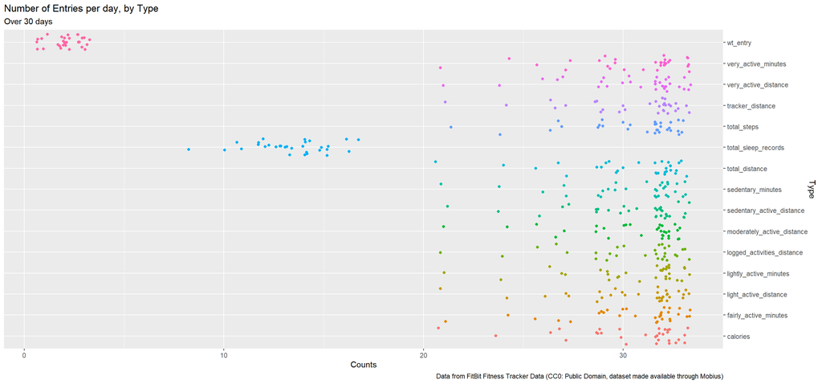

These plots show that users appear to primarily use their devices to track activity. Similar to the participation plot above this shows that the fewest number of entries were for weights, followed by sleep.

[figure not shown]

Another potential trend worth noting is the decrease in entries overall towards the end of the data collection period, as seen below. This could indicate that while users were willing to give access to their data to the provider, for analysis, that they may have started the period off more engaged while losing some interest in tracking data towards the end of the 30 day period. This could indicate an external motivation for activity by many users, capabilities for competing with friends and strangers on challenges may motive users to engage and track more.

#### Diligence in tracking

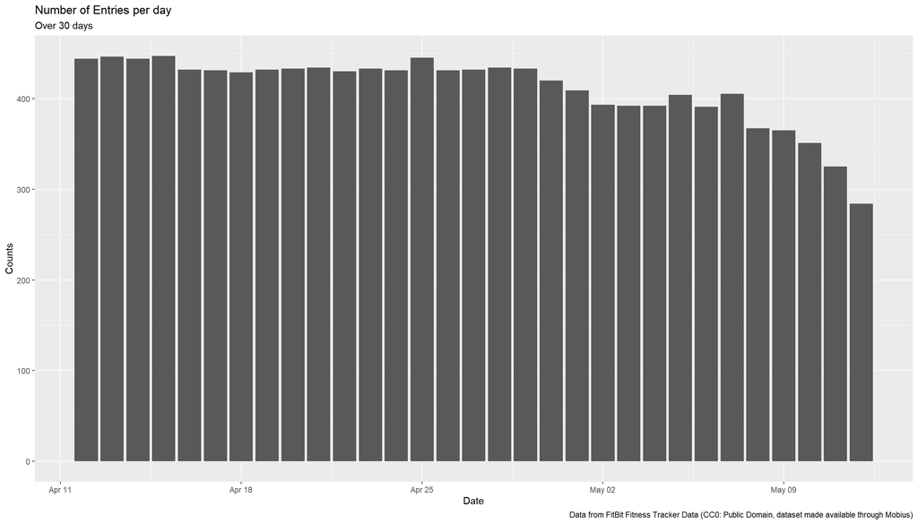

#### Sleep tracking

One more trend noticed… sleep tracking appeared to fluctuate the most in cycles of approximately 3 days, one hypothesis is that users need to charge their devices and may be doing that while they are sleep so as to not lose out on tracking the information they are most interested in tracking. This hypothesis would need further exploration before any recommendations could be made specifically, however, a quick charge ability may help if this is in fact the case.

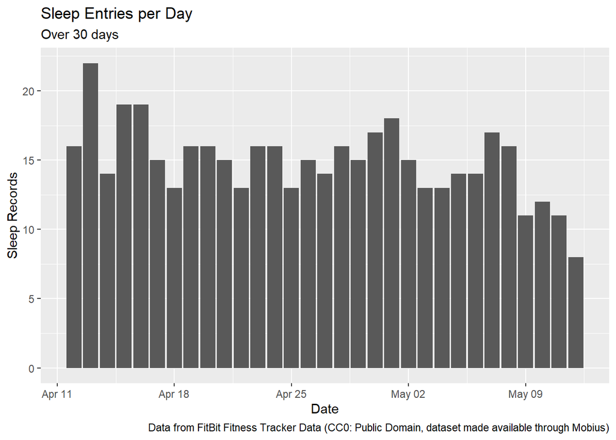

The questions we started with:

**- What are some trends in smart device usage?**

- Trends have been identified above in the “Trends” section.

**- How could these trends apply to Bellabeat customers?**

- These trends provide an opportunity for Bellabeat to create an interactive environment for their users where they are encouraged to move more and rest well without an emphasis on weight loss or gain.